# cdasws Binning Example Jupyter Notebook

This [Jupyter notebook](https://jupyter.org) demonstrates using the cdasws Python package to retrieve data from two [cdaweb](https://cdaweb.gsfc.nasa.gov) datasets that have different timestamps and places the data on the same time grid (with optional spike removal). The data is returned in the [SpacePy data model](https://spacepy.github.io/datamodel.html). The AC_H0_SWE and AC_H2_SWE datasets are used in this example. For more information on binning, see [binning in cdaweb](https://cdaweb.gsfc.nasa.gov/CDAWeb_Binning_readme.html).

This notebook contains the following sections:

1. Prerequisites
2. Setup
3. Display Original Data
4. Get Binned Data
5. Compare Data
6. Additional Documentation

## Prerequisites

Install the prerequisite software the [Python Package Index](https://pypi.org/)

```python
%pip install spacepy cdasws -q
```

## Setup

Execute some preliminary code that is necessary before the code that follows.

```python
from cdasws.cdasws import CdasWs

import matplotlib.pyplot as plt

cdas = CdasWs()
```

## Display Original Data

The following code gets and displays the original, unbinned data.

```python
dataset0 = 'AC_H0_SWE'
parameters = ['Np']
start = '1998-02-04T00:00:00Z'
stop = '1998-02-06T00:00:00Z'
status, data0 = cdas.get_data(dataset0, parameters, start, stop)
print(f'{dataset0}')
print(data0)
dataset1 = 'AC_H2_SWE'
status, data1 = cdas.get_data(dataset1, parameters, start, stop)
print()
print(f'{dataset1}')
print(data1)
```

```
AC_H0_SWE
{'Epoch': VarCopy([datetime.datetime(1998, 2, 4, 0, 0, 31),
         datetime.datetime(1998, 2, 4, 0, 1, 35),
         datetime.datetime(1998, 2, 4, 0, 2, 39), ...,
         datetime.datetime(1998, 2, 5, 23, 57, 19),
         datetime.datetime(1998, 2, 5, 23, 58, 23),
         datetime.datetime(1998, 2, 5, 23, 59, 27)], dtype=object), 'Np': VarCopy([-1.00000e+31, -1.00000e+31, -1.00000e+31, ...,  1.44819e+01,
          1.49483e+01,  1.35783e+01], dtype=float32)}

AC_H2_SWE
{'Epoch': VarCopy([datetime.datetime(1998, 2, 4, 0, 0),
         datetime.datetime(1998, 2, 4, 1, 0),
         datetime.datetime(1998, 2, 4, 2, 0),
         datetime.datetime(1998, 2, 4, 3, 0),
         datetime.datetime(1998, 2, 4, 4, 0),
         datetime.datetime(1998, 2, 4, 5, 0),
         datetime.datetime(1998, 2, 4, 6, 0),
         datetime.datetime(1998, 2, 4, 7, 0),
         datetime.datetime(1998, 2, 4, 8, 0),
         datetime.datetime(1998, 2, 4, 9, 0),
         datetime.datetime(1998, 2, 4, 10, 0),
         datetime.datetime(1998, 2, 4, 11, 0),
         datetime.datetime(1998, 2, 4, 12, 0),
         datetime.datetime(1998, 2, 4, 13, 0),
         datetime.datetime(1998, 2, 4, 14, 0),
         datetime.datetime(1998, 2, 4, 15, 0),
         datetime.datetime(1998, 2, 4, 16, 0),
         datetime.datetime(1998, 2, 4, 17, 0),
         datetime.datetime(1998, 2, 4, 18, 0),
         datetime.datetime(1998, 2, 4, 19, 0),
         datetime.datetime(1998, 2, 4, 20, 0),
         datetime.datetime(1998, 2, 4, 21, 0),
         datetime.datetime(1998, 2, 4, 22, 0),
         datetime.datetime(1998, 2, 4, 23, 0),
         datetime.datetime(1998, 2, 5, 0, 0),
         datetime.datetime(1998, 2, 5, 1, 0),
         datetime.datetime(1998, 2, 5, 2, 0),
         datetime.datetime(1998, 2, 5, 3, 0),
         datetime.datetime(1998, 2, 5, 4, 0),
         datetime.datetime(1998, 2, 5, 5, 0),
```

[output cut: 16 more lines]

```
         datetime.datetime(1998, 2, 5, 22, 0),
         datetime.datetime(1998, 2, 5, 23, 0),
         datetime.datetime(1998, 2, 6, 0, 0)], dtype=object), 'Np': VarCopy([-1.00000e+31, -1.00000e+31, -1.00000e+31, -1.00000e+31,
         -1.00000e+31, -1.00000e+31, -1.00000e+31, -1.00000e+31,
         -1.00000e+31, -1.00000e+31, -1.00000e+31, -1.00000e+31,
         -1.00000e+31, -1.00000e+31, -1.00000e+31, -1.00000e+31,
         -1.00000e+31, -1.00000e+31, -1.00000e+31, -1.00000e+31,
         -1.00000e+31, -1.00000e+31, -1.00000e+31,  1.50185e+01,
          1.66551e+01,  2.06010e+01,  1.86789e+01,  1.84808e+01,
          2.83151e+01,  2.29591e+01,  2.67127e+01,  2.87503e+01,
          3.11556e+01,  2.98451e+01,  2.96215e+01,  3.19601e+01,
          2.88363e+01,  2.34173e+01,  2.58818e+01,  2.50207e+01,
          2.76192e+01,  2.56742e+01,  2.56151e+01,  2.00080e+01,
          1.49786e+01,  1.20008e+01,  1.34287e+01,  1.04862e+01,
          1.06203e+01], dtype=float32)}
```

## Get Binned Data

The following code gets data after it has been binned with 60 second time intervals and any missing values created by interpolation.

```python
binData = {
    'interval': 60.0,
    'interpolateMissingValues': True,
    'sigmaMultiplier': 4
}
status, data0 = cdas.get_data(dataset0, parameters, start, stop, binData=binData)
print(f'{dataset0}')
print(data0)
status, data1 = cdas.get_data(dataset1, parameters, start, stop, binData=binData)
print()
print(f'{dataset1}')
print(data1)
```

```
AC_H0_SWE
{'Epoch_bin': VarCopy([datetime.datetime(1998, 2, 4, 0, 0, 30),
         datetime.datetime(1998, 2, 4, 0, 1, 30),
         datetime.datetime(1998, 2, 4, 0, 2, 30), ...,
         datetime.datetime(1998, 2, 5, 23, 57, 30),
         datetime.datetime(1998, 2, 5, 23, 58, 30),
         datetime.datetime(1998, 2, 5, 23, 59, 30)], dtype=object), 'Epoch': VarCopy([datetime.datetime(1998, 2, 4, 0, 0, 31),
         datetime.datetime(1998, 2, 4, 0, 1, 35),
         datetime.datetime(1998, 2, 4, 0, 2, 39), ...,
         datetime.datetime(1998, 2, 5, 23, 57, 19),
         datetime.datetime(1998, 2, 5, 23, 58, 23),
         datetime.datetime(1998, 2, 5, 23, 59, 27)], dtype=object), 'Np': VarCopy([16.3343, 16.3343, 16.3343, ..., 14.4819, 14.9483, 13.5783],
        dtype=float32), 'NP_NBIN': VarCopy([-0., -0., -0., ...,  1.,  1.,  1.], dtype=float32), 'NP_BIN_DELTA_MINUS_VAR': VarCopy([-1.e+31, -1.e+31, -1.e+31, ..., -1.e+31, -1.e+31, -1.e+31],
        dtype=float32), 'NP_BIN_DELTA_PLUS_VAR': VarCopy([-1.e+31, -1.e+31, -1.e+31, ..., -1.e+31, -1.e+31, -1.e+31],
        dtype=float32)}

AC_H2_SWE
{'Epoch_bin': VarCopy([datetime.datetime(1998, 2, 4, 0, 0, 30),
         datetime.datetime(1998, 2, 4, 0, 1, 30),
         datetime.datetime(1998, 2, 4, 0, 2, 30), ...,
         datetime.datetime(1998, 2, 5, 23, 57, 30),
         datetime.datetime(1998, 2, 5, 23, 58, 30),
         datetime.datetime(1998, 2, 5, 23, 59, 30)], dtype=object), 'Epoch': VarCopy([datetime.datetime(1998, 2, 4, 0, 0),
         datetime.datetime(1998, 2, 4, 1, 0),
         datetime.datetime(1998, 2, 4, 2, 0),
         datetime.datetime(1998, 2, 4, 3, 0),
         datetime.datetime(1998, 2, 4, 4, 0),
         datetime.datetime(1998, 2, 4, 5, 0),
         datetime.datetime(1998, 2, 4, 6, 0),
         datetime.datetime(1998, 2, 4, 7, 0),
         datetime.datetime(1998, 2, 4, 8, 0),
         datetime.datetime(1998, 2, 4, 9, 0),
         datetime.datetime(1998, 2, 4, 10, 0),
         datetime.datetime(1998, 2, 4, 11, 0),
         datetime.datetime(1998, 2, 4, 12, 0),
         datetime.datetime(1998, 2, 4, 13, 0),
         datetime.datetime(1998, 2, 4, 14, 0),
         datetime.datetime(1998, 2, 4, 15, 0),
         datetime.datetime(1998, 2, 4, 16, 0),
         datetime.datetime(1998, 2, 4, 17, 0),
```

[output cut: 19 more lines]

```
         datetime.datetime(1998, 2, 5, 13, 0),
         datetime.datetime(1998, 2, 5, 14, 0),
         datetime.datetime(1998, 2, 5, 15, 0),
         datetime.datetime(1998, 2, 5, 16, 0),
         datetime.datetime(1998, 2, 5, 17, 0),
         datetime.datetime(1998, 2, 5, 18, 0),
         datetime.datetime(1998, 2, 5, 19, 0),
         datetime.datetime(1998, 2, 5, 20, 0),
         datetime.datetime(1998, 2, 5, 21, 0),
         datetime.datetime(1998, 2, 5, 22, 0),
         datetime.datetime(1998, 2, 5, 23, 0),
         datetime.datetime(1998, 2, 6, 0, 0)], dtype=object), 'Np': VarCopy([16.6551, 16.6551, 16.6551, ..., 10.4862, 10.4862, 10.4862],
        dtype=float32), 'NP_NBIN': VarCopy([-0., -0., -0., ..., -0., -0., -0.], dtype=float32), 'NP_BIN_DELTA_MINUS_VAR': VarCopy([-1.e+31, -1.e+31, -1.e+31, ..., -1.e+31, -1.e+31, -1.e+31],
        dtype=float32), 'NP_BIN_DELTA_PLUS_VAR': VarCopy([-1.e+31, -1.e+31, -1.e+31, ..., -1.e+31, -1.e+31, -1.e+31],
        dtype=float32)}
```

## Compare Data

The following code compares the binned data from the two datasets by plotting the values.

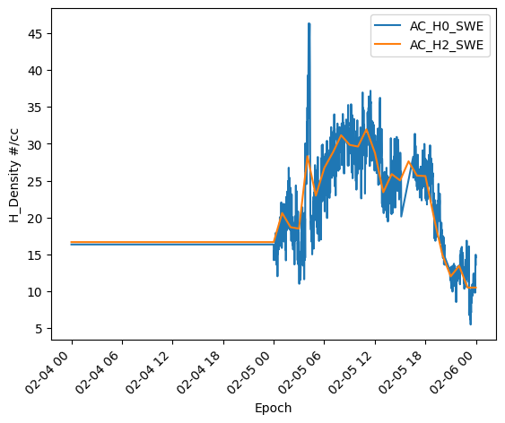

```python
plt.plot(data0['Epoch_bin'], data0['Np'])
plt.plot(data1['Epoch_bin'], data1['Np'])
plt.xlabel(data0['Epoch'].attrs['LABLAXIS'])
plt.xticks(rotation=45, ha='right')
plt.ylabel(data0['Np'].attrs['LABLAXIS'] + ' ' +
           data0['Np'].attrs['UNITS'])
plt.legend([dataset0, dataset1])
plt.show()
```

## Additional Documentation

View the [cdasws API](https://berniegsfc.github.io/cdasws/py/api/cdasws.html) for additional functions. Additional [notebook examples](https://berniegsfc.github.io/cdasws/#Jupyter_Notebook_Examples) are also available.